# 6th-Mar-Assignment

Q1. What is Statistics?

Statistics is the study of the collection, analysis, interpretation, presentation, and organization of data. It involves using mathematical methods to analyze and make inferences from large datasets, with the aim of gaining insight and making predictions about the underlying population from which the data was collected. Statistics can be used to describe the characteristics of a population, test hypotheses about relationships between variables, and make predictions about future events. It is widely used in fields such as business, finance, healthcare, and social sciences, and plays an important role in decision-making in many different industries. There are two main branches of statistics: descriptive statistics and inferential statistics. Descriptive statistics involves summarizing and presenting data in a meaningful way, while inferential statistics involves using sample data to make predictions or draw conclusions about a larger population.

Q2. Define the different types of statistics and give an example of when each type might be used.

There are two main types of statistics: descriptive statistics and inferential statistics. Descriptive statistics: Descriptive statistics refers to the techniques used to summarize and describe data. It involves the calculation of measures such as mean, median, mode, range, and standard deviation. Descriptive statistics is often used to provide a visual or numerical summary of data, to understand the distribution of data, or to identify patterns and trends in the data. For example, a market research firm may use descriptive statistics to summarize the results of a customer satisfaction survey by calculating the average rating of different products and identifying the most popular product. Inferential statistics: Inferential statistics refers to the techniques used to make inferences about a population based on a sample of data. It involves the estimation of population parameters, hypothesis testing, and the use of probability theory. Inferential statistics is often used to make predictions or draw conclusions about a larger population based on a smaller sample of data. For example, a medical researcher may use inferential statistics to test whether a new drug is effective by comparing the results of a treatment group and a control group. In summary, descriptive statistics is used to summarize and describe data, while inferential statistics is used to make inferences and predictions about a larger population based on a smaller sample of data.

Q3. What are the different types of data and how do they differ from each other? Provide an example of each type of data

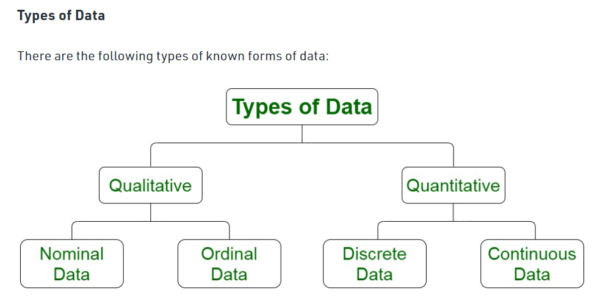

There are four main types of data: qualitative (nominal and ordinal) and quantitative (discrete and continuous). Qualitative Data: Qualitative data is descriptive in nature and represents some attributes or characteristics of the data. This type of data can't be measured or calculated and is non-numerical. It is further divided into two subtypes: nominal and ordinal. Nominal Data: Nominal data is used to label variables without providing numerical values. It can be both qualitative and quantitative in nature. Examples of nominal data include gender, eye color, hair color, and marital status. Ordinal Data: Ordinal data is a type of data that follows a natural order, and the difference between data values is not determined. Examples of ordinal data include customer level of satisfaction (very satisfied, satisfied, neutral, dissatisfied, very dissatisfied), feedback ratings, education level, and letter grades. Quantitative Data: Quantitative data is numerical in nature and can be measured and calculated. This type of data is further divided into two subtypes: discrete and continuous. Discrete Data: Discrete data refers to data values that can only attain specific values and can't attain a range of values. Examples of discrete data include the number of students in a class, the number of chips in a bag, and the number of stars in the sky. Continuous Data: Continuous data refers to data values that can contain values between a certain range, and the corresponding difference between the highest and lowest value of these intervals can be termed as the range of data. Examples of continuous data include height and weight of a student, daily temperature recordings of a place, and wind speed measurement. In summary, the main difference between these types of data is their nature, measurement, and calculation. Qualitative data is descriptive, while quantitative data is numerical. Nominal and ordinal data are subtypes of qualitative data, while discrete and continuous data are subtypes of quantitative data.

Q4. Categorise the following datasets with respect to quantitative and qualitative data types:

(i) Grading in exam: A+, A, B+, B, C+, C, D, E

(ii) Colour of mangoes: yellow, green, orange, red

(iii) Height data of a class: [178.9, 179, 179.5, 176, 177.2, 178.3, 175.8,...]

(iv) Number of mangoes exported by a farm: [500, 600, 478, 672, ...]

i) Grading in exam: A+, A, B+, B, C+, C, D, E Ordinal data (since grades have a natural ordering from highest to lowest, but the difference between the grades is not uniform) (ii) Colour of mangoes: yellow, green, orange, red Nominal data (since there is no inherent order or ranking to the different colors) (iii) Height data of a class: [178.9, 179, 179.5, 176, 177.2, 178.3, 175.8,...] Continuous data (since height can take any value within a range) (iv) Number of mangoes exported by a farm: [500, 600, 478, 672, ...] Discrete data (since the number of mangoes is a countable quantity, and cannot take fractional values)

Q5. Explain the concept of levels of measurement and give an example of a variable for each level.

Levels of measurement refer to the ways in which variables can be categorized based on the properties of the values they take. There are four levels of measurement: nominal, ordinal, interval, and ratio. Nominal level of measurement: This level of measurement involves assigning names or labels to different categories. Nominal variables have no inherent order or numerical meaning. Examples of nominal variables include gender (male, female, non-binary), race (White, Black, Asian, etc.), and political affiliation (Republican, Democrat, Independent). Ordinal level of measurement: This level of measurement involves categorizing data based on the relative order or ranking of the values. Ordinal variables have a natural order, but the differences between values are not equal or meaningful. Examples of ordinal variables include educational attainment (less than high school, high school graduate, some college, Bachelor's degree, etc.), socioeconomic status (low, middle, high), and star ratings (1 star, 2 stars, 3 stars, 4 stars, 5 stars). Interval level of measurement: This level of measurement involves assigning numerical values to data points where the difference between values is equal and meaningful, but there is no true zero point. Examples of interval variables include temperature (measured in Celsius or Fahrenheit), dates (measured in days since a certain starting point), and IQ scores. Ratio level of measurement: This level of measurement involves assigning numerical values to data points where there is a true zero point, meaning that the absence of the variable is meaningful. Examples of ratio variables include height, weight, distance, and time.

Q6. Why is it important to understand the level of measurement when analyzing data? Provide an example to illustrate your answer

It is important to understand the level of measurement when analyzing data because different statistical methods and techniques are appropriate for different types of data. Using the wrong statistical method or technique for a particular type of data can lead to inaccurate results and conclusions. For example, if you have nominal data, such as the colors of different types of fruits, you cannot calculate a mean or standard deviation, because these calculations require numerical values. Instead, you would use frequency distributions or chi-square tests to analyze the data. On the other hand, if you have continuous data, such as the heights of individuals in a population, you can calculate a mean and standard deviation, and use methods such as regression analysis or ANOVA to analyze the data. Additionally, understanding the level of measurement can also help in choosing the appropriate visual representation of the data. For example, nominal data is typically represented by bar graphs or pie charts, while continuous data is represented by histograms or scatter plots. In summary, understanding the level of measurement is crucial for selecting the appropriate statistical methods, techniques, and visual representations to analyze and interpret the data accurately.

Q7. How nominal data type is different from ordinal data type.

Nominal and ordinal data are both types of categorical data, but they differ in their level of measurement and the nature of the categories they represent. Nominal data is a type of categorical data where the categories do not have any inherent order or ranking. This means that the categories are only named and do not have any quantitative value associated with them. Examples of nominal data include gender, race, religion, and type of car. Ordinal data, on the other hand, is a type of categorical data where the categories have a natural order or ranking. The categories can be ranked or ordered based on some characteristic or attribute. However, the difference between the categories is not necessarily equal or consistent. Examples of ordinal data include education level (e.g. high school, college, graduate school), customer satisfaction ratings (e.g. poor, fair, good, excellent), and socioeconomic status (e.g. low, middle, high). In summary, the key difference between nominal and ordinal data is that nominal data has categories that do not have any inherent order or ranking, while ordinal data has categories that have a natural order or ranking.

Q8. Which type of plot can be used to display data in terms of range?

A box plot or box and whisker plot is commonly used to display data in terms of range. This type of plot shows the distribution of a dataset, including the minimum and maximum values, the median (or middle) value, and the first and third quartiles. In a box plot, a box is drawn around the middle 50% of the data, with a line inside the box representing the median value. Lines, called whiskers, extend from the box to the minimum and maximum values. Outliers may be plotted individually as points outside the whiskers. Box plots are useful for identifying the spread and skewness of a dataset, as well as any potential outliers. They are often used in exploratory data analysis and in comparing the distributions of multiple datasets. Other types of plots that can be used to display data in terms of range include range plots and dot plots, but box plots are generally preferred because they provide more information about the distribution of the data

Q9. Describe the difference between descriptive and inferential statistics. Give an example of each types of statistics and how they are used

Descriptive and inferential statistics are two types of statistical analysis that are used to summarize and interpret data in different ways. Descriptive statistics are used to summarize and describe the main features of a dataset. This includes measures of central tendency (e.g., mean, median, mode), measures of variability (e.g., range, standard deviation), and measures of distribution (e.g., histograms, frequency tables). Descriptive statistics are useful for organizing and presenting data in a meaningful way, but they do not allow for generalizations or predictions beyond the specific dataset being analyzed. For example, if we have a dataset of exam scores for a class, we could use descriptive statistics to calculate the mean score, standard deviation, and range of scores. We could also create a histogram or frequency table to show the distribution of scores in the class. Inferential statistics, on the other hand, are used to draw conclusions and make predictions about a larger population based on a sample of data. This involves using probability theory and statistical methods to test hypotheses and make inferences about the population parameters. Inferential statistics are useful for making predictions and generalizations beyond the specific dataset being analyzed, but they require assumptions about the sample and population, and they are subject to potential errors and biases. For example, if we have a sample of exam scores for a class, we could use inferential statistics to test hypotheses about the mean score or the proportion of students who passed the exam. We could also use inferential statistics to make predictions about the exam scores of the entire class or future classes based on the sample data. In summary, descriptive statistics are used to summarize and describe the main features of a dataset, while inferential statistics are used to draw conclusions and make predictions about a larger population based on a sample of data. Both types of statistics are important in data analysis, and they serve different purposes and require different methods and techniques.

Q10. What are some common measures of central tendency and variability used in statistics? Explain how measue can be used to describe dataset

There are several common measures of central tendency and variability used in statistics. These measures help to describe the distribution of a dataset by summarizing its main features, such as the typical or average value, the spread or variability of the data, and the shape of the distribution. Measures of central tendency include: Mean: The mean is the most common measure of central tendency, and it represents the average value of the dataset. It is calculated by summing all the values in the dataset and dividing by the total number of values. The mean is sensitive to outliers and can be influenced by extreme values. Median: The median is the middle value in the dataset when the values are ordered from smallest to largest. It is a robust measure of central tendency that is not affected by outliers, and it provides information about the middle value of the distribution. Mode: The mode is the value that occurs most frequently in the dataset. It is useful for identifying the most common value or category in the dataset, and it can be used for both numerical and categorical data. Measures of variability include: Range: The range is the difference between the largest and smallest values in the dataset. It provides information about the spread of the data, but it is sensitive to outliers and can be influenced by extreme values. Standard deviation: The standard deviation measures the average distance of each value from the mean. It is a common measure of variability that is useful for understanding the spread of the data, and it is less sensitive to outliers than the range. Interquartile range: The interquartile range (IQR) is the difference between the third and first quartiles of the dataset. It provides information about the middle 50% of the data, and it is a robust measure of variability that is not affected by outliers. Each of these measures of central tendency and variability can be used to describe different aspects of a dataset. For example, the mean and median can provide information about the typical value of the data, while the range, standard deviation, and IQR can provide information about the spread or variability of the data. Understanding these measures is essential for interpreting and communicating statistical results accurately and effectively.